# R tutorial

## Vectors

An object can also be a vector of more than one value. Combining two or more values is done by using the `c()` command.

```r
# A sequence of numbers can be generated by using :
vec1 <- 1:40
vec1
```

```
##  [1]  1  2  3  4  5  6  7  8  9 10 11 12 13 14 15 16 17 18 19 20 21 22 23 24 25
## [26] 26 27 28 29 30 31 32 33 34 35 36 37 38 39 40
```

```r
# Other vectors can be made using the c() command to combine multiple values.
vec2 <- c(1.3, 2.9, 6.6, 3.0, 8.4)
vec2
```

```
## [1] 1.3 2.9 6.6 3.0 8.4
```

Values in a vector must be of the same type. If values are of different types, R will coerce them to be the same type. If R cannot coerce, it will replace the value with `NA`.

```r
vec3 <- c(1, "blue", 9)
vec3
```

```
## [1] "1"    "blue" "9"
```

An empty vector can be defined using the `vector()` function.

```r
vec4 <- vector("numeric", length = 10)
vec4
```

```
##  [1] 0 0 0 0 0 0 0 0 0 0
```

If a vector contains integers or numeric data, arithmetic operations can be executed on it.

```r
vec1
```

```
##  [1]  1  2  3  4  5  6  7  8  9 10 11 12 13 14 15 16 17 18 19 20 21 22 23 24 25
## [26] 26 27 28 29 30 31 32 33 34 35 36 37 38 39 40
```

```r
vec1 / 4
```

```
##  [1]  0.25  0.50  0.75  1.00  1.25  1.50  1.75  2.00  2.25  2.50  2.75  3.00
## [13]  3.25  3.50  3.75  4.00  4.25  4.50  4.75  5.00  5.25  5.50  5.75  6.00
## [25]  6.25  6.50  6.75  7.00  7.25  7.50  7.75  8.00  8.25  8.50  8.75  9.00
## [37]  9.25  9.50  9.75 10.00
```

Functions in R can also work on vectors.

```r
mean(vec1)
```

```
## [1] 20.5
```

```r
sum(vec1)
```

```
## [1] 820
```

Logical operations can work on vectors.

```r
vec2
```

```
## [1] 1.3 2.9 6.6 3.0 8.4
```

```r
vec2 > 3
```

```
## [1] FALSE FALSE  TRUE FALSE  TRUE
```

```r
vec2 >= 3
```

```
## [1] FALSE FALSE  TRUE  TRUE  TRUE
```

An element of a vector is extracted using the position number of the element inside single brackets: `[ ]`. Consecutive elements are extracted by using the start and end position separated by `:`. Nonconsecutive elements require the `c()` function.

```r
vec2[2]
```

```
## [1] 2.9
```

```r
vec2[2:5]
```

```
## [1] 2.9 6.6 3.0 8.4
```

```r
vec2[c(2, 4)]
```

```
## [1] 2.9 3.0
```

A vector can also be subsetted by using a logical operation, extracting the elements for which the condition is `TRUE`.

```r
vec2 < 4
```

```
## [1]  TRUE  TRUE FALSE  TRUE FALSE
```

```r
vec2
```

```
## [1] 1.3 2.9 6.6 3.0 8.4
```

```r
vec2[vec2 < 4]
```

```
## [1] 1.3 2.9 3.0
```

```r
vec2[vec2 >= 4]
```

```
## [1] 6.6 8.4
```

## Lists

Unlike vectors or matrices, lists can contain different datatypes. Lists can even contain other lists. As such, they can have a complex structure.

```r
list1 <- list("a", 1, 6.3)
list1
```

```
## [[1]]
## [1] "a"
##
## [[2]]
## [1] 1
##
## [[3]]
## [1] 6.3
```

Notice the more separated organization of lists.

```r
list2 <- list(18, list1, c("G", "A", "T", "C"))
list2
```

```
## [[1]]
## [1] 18
##
## [[2]]
## [[2]][[1]]
## [1] "a"
##
## [[2]][[2]]
## [1] 1
##
## [[2]][[3]]
## [1] 6.3
##
##
## [[3]]
## [1] "G" "A" "T" "C"
```

Due to their complex structure, lists are subsetted differently from vectors. Single brackets will extract elements as lists, while double brackets can extract elements as other datatypes.

```r
list2[1]         # extract the first element of list2 as a list
```

```
## [[1]]
## [1] 18
```

```r
class(list2[1])
```

```
## [1] "list"
```

```r
list2[[1]]       # extract the first element of list2 as a value
```

```
## [1] 18
```

```r
class(list2[[1]])
```

```
## [1] "numeric"
```

```r
list2[3]         # extract the third element of list2 as a list
```

```
## [[1]]
## [1] "G" "A" "T" "C"
```

```r
list2[[3]]       # extract the third element of list2 as a vector
```

```
## [1] "G" "A" "T" "C"
```

```r
list2[[3]][1:2]  # extract a subset of the third element
```

```
## [1] "G" "A"
```

## Matrices

Matrices are two-dimensional sets of data consisting of columns and rows in which all of the values are of a single type (e.g. numeric). Much bioinformatic data is created in matrices (usually numeric), which can affect how it is read into R.

```r
mat1 <- matrix(c(1:4, 11:14, 21:24), nrow = 4, ncol = 3, byrow = FALSE)
mat1
```

```
##      [,1] [,2] [,3]
## [1,]    1   11   21
## [2,]    2   12   22
## [3,]    3   13   23
## [4,]    4   14   24
```

```r
rownames(mat1) <- c("gene1", "gene2", "gene3", "gene4")
colnames(mat1) <- c("expt1", "expt2", "expt3")
```

The elements of a matrix can be extracted using the syntax `matrix_name[row_number, col_number]`.

```r
mat1[1, ]
```

```
## expt1 expt2 expt3
##     1    11    21
```

```r
mat1[, 2]
```

```
## gene1 gene2 gene3 gene4
##    11    12    13    14
```

```r
mat1[4, 3]
```

```
## [1] 24
```

```r
mat1[2:3, ]
```

```
##       expt1 expt2 expt3
## gene2     2    12    22
## gene3     3    13    23
```

## Dataframes

Like matrices, dataframes are datasets with rows and columns. Unlike matrices, dataframes can have multiple datatypes such as integer and character, although every column has a defined datatype. As such, a dataframe most closely resembles data in an Excel spreadsheet, although one that is perfectly rectangular. Because dataframes can contain different datatypes, they are a special kind of list, a list of vectors (columns) in which each vector has the same length.

```r
df1 <- data.frame(x = 1:3, y = c("a", "b", "c"), z = c(TRUE, TRUE, FALSE))
df1
```

| x | y | z |
| --- | --- | --- |
| 1 | a | TRUE |
| 2 | b | TRUE |
| 3 | c | FALSE |

Because dataframe columns must all be of the same length, missing data will be replaced by `NA`.

```r
dim(df1)  # to see the dimensions of a dataframe (rows, columns)
```

```
## [1] 3 3
```

```r
str(df1)  # to see details about the columns of a dataframe
```

```
## 'data.frame':    3 obs. of  3 variables:
##  $ x: int  1 2 3
##  $ y: chr  "a" "b" "c"
##  $ z: logi  TRUE TRUE FALSE
```

```r
summary(df1)  # to get some summary statistics for the columns
```

```
##        x            y                 z
##  Min.   :1.0   Length:3           Mode :logical
##  1st Qu.:1.5   Class :character   FALSE:1
##  Median :2.0   Mode  :character   TRUE :2
##  Mean   :2.0
##  3rd Qu.:2.5
##  Max.   :3.0
```

Data can be extracted from dataframes in various ways. Like matrices, dataframes can be subsetted using the syntax `df_name[row_number, col_number]`.

```r
df1[1, ]  # extract the first row from df1 as a dataframe
```

| x | y | z |
| --- | --- | --- |
| 1 | a | TRUE |

```r
df1[, 3]  # extract the third column from df1
```

```
## [1]  TRUE  TRUE FALSE
```

```r
df1[2, 3] # extract the value in the second row, third column
```

```
## [1] TRUE
```

A column can be extracted from a dataframe using the `$` operator. Logical values can also be used to extract.

```r
df1$x     # extract the column named "x" from df1 as a vector
```

```
## [1] 1 2 3
```

```r
df1[df1$x == 2, ]  # extract the row where x = 2
```

|  | x | y | z |
| --- | --- | --- | --- |
| 2 | 2 | b | TRUE |

```r
df1[df1$z == TRUE, ]  # extract the rows where z = TRUE
```

| x | y | z |
| --- | --- | --- |
| 1 | a | TRUE |
| 2 | b | TRUE |

The column names can be seen or modified using `colnames()`.

```r
colnames(df1)
```

```
## [1] "x" "y" "z"
```

```r
bind_cols(df1, d = 4:6)
```

| x | y | z | d |
| --- | --- | --- | --- |
| 1 | a | TRUE | 4 |
| 2 | b | TRUE | 5 |
| 3 | c | FALSE | 6 |

```r
colnames(df1) <- c("a", "b", "c")
df1
```

| a | b | c |
| --- | --- | --- |
| 1 | a | TRUE |
| 2 | b | TRUE |
| 3 | c | FALSE |

```r
df1$x    # no longer works due to renaming!
```

Values within a dataframe can be overwritten.

```r
df1
```

| a | b | c |
| --- | --- | --- |
| 1 | a | TRUE |
| 2 | b | TRUE |
| 3 | c | FALSE |

```r
df1[2, 3] <- NA
df1
```

| a | b | c |
| --- | --- | --- |
| 1 | a | TRUE |
| 2 | b | NA |
| 3 | c | FALSE |

# Functions

R has a number of built-in functions, while other functions are contained within packages. In addition, users can create their own functions. Functions are composed of the function name followed by parentheses in which arguments are provided, either mandatory or optional. Some functions can work without arguments. For example, the following function shows the current date and time:

```r
date()
```

An example of a function that requires an argument is `mean()`. If we look at the help page for `mean()`, the structure of the command is:  
`mean(x, trim = 0, na.rm = FALSE, ...)`  
`x` is a mandatory object, the data for which the mean is calculated. The remaining arguments are optional and have their default values shown. We do not need to define them unless the default value is not desired.

```r
sample1 <- c(8, 12, 5, 13, 7)
mean(sample1)
```

```
## [1] 9
```

```r
# If the vector contains NA values, mean() returns NA.
sample2 <- c(8, 12, 5, 13, 7, NA)
mean(sample2)
```

```
## [1] NA
```

```r
# We can define the na.rm argument (remove NA) to ignore NA values.
mean(sample2, na.rm = TRUE)
```

```
## [1] 9
```

User-defined functions are created using the `function()` command and curly braces `{}`. If we want to write a function to calculate the length of the hypotenuse of a right triangle given the lengths of the two sides, the syntax is:

```r
hyp <- function(side1, side2) {
      sqrt((side1 ^ 2) + (side2 ^ 2))
}
hyp(3, 4)
```

```
## [1] 5
```

```r
hyp(5, 12)
```

```
## [1] 13
```

`hyp(12)` returns an error because the function requires two arguments.

# The tidyverse package suite

Many bioinformatics workflows you will encounter will use the syntax of base R. The base R functions are universally available. However, many of them are not intuitive to learn or use. The `tidyverse` family of packages were created by Hadley Wickham and collaborators to provide a large number of functions that work well together to powerfully manipulate data.

- readr - to read in two-dimensional data
- tidyr - for data organization
- dplyr - for data manipulation
- tibble - a modified approach to dataframes
- stringr - to work with character strings
- ggplot2 - for graphics
- forcats - for factors
- purrr - to work with functions, vectors, and lists

We will work with dplyr commands to manipulate data and ggplot2 to visualize it. We can load each package separately, but loading the tidyverse is easier.

```r
library(tidyverse)
```

Although tidyverse commands can be used with a variety of objects, it is designed to work on dataframes. The commands are intended to manipulate a two-dimensional data table, much like what we typically encounter in Excel. However, the way in which the tidyverse functions requires a profound re-thinking of how we organize our data.

The tidyverse works on the premise of “tidy data”. For a dataframe, tidy data means that each row is an observation and each column a variable. A common challenge we face in data science is untidy data: inconsistent values, incorrect datatypes, or missing values. Much of the work with such data is in cleaning it up for downstream analysis.

R provides a variety of preloaded datasets for users to practice with; a list can be seen by typing `data()` into the console. We will be using the `mtcars` dataset that contains data from *Motor Trend* magazine in 1974 for 32 different models of cars, and is a useful dataset to manipulate and visualize. To see the contents of the `mtcars` dataset, type `?mtcars`.

# dplyr functions

- `%>%` - the pipe operator, similar to `|` in Linux
- `select` - choose columns
- `filter` - choose rows based on conditions
- `arrange` - sort rows based on column values
- `mutate` - convert data in an existing column into new data in a new column
- `summarize` - provide summary data for a column
- `group_by` - group data based on a variable; often used with summarize

We have several ways to get an idea of the structure and contents of a dataset.

```r
head(mtcars)       # to see the first six lines
```

|  | mpg | cyl | disp | hp | drat | wt | qsec | vs | am | gear | carb |
| --- | --- | --- | --- | --- | --- | --- | --- | --- | --- | --- | --- |
| Mazda RX4 | 21.0 | 6 | 160 | 110 | 3.90 | 2.620 | 16.46 | 0 | 1 | 4 | 4 |
| Mazda RX4 Wag | 21.0 | 6 | 160 | 110 | 3.90 | 2.875 | 17.02 | 0 | 1 | 4 | 4 |
| Datsun 710 | 22.8 | 4 | 108 | 93 | 3.85 | 2.320 | 18.61 | 1 | 1 | 4 | 1 |
| Hornet 4 Drive | 21.4 | 6 | 258 | 110 | 3.08 | 3.215 | 19.44 | 1 | 0 | 3 | 1 |
| Hornet Sportabout | 18.7 | 8 | 360 | 175 | 3.15 | 3.440 | 17.02 | 0 | 0 | 3 | 2 |
| Valiant | 18.1 | 6 | 225 | 105 | 2.76 | 3.460 | 20.22 | 1 | 0 | 3 | 1 |

```r
str(mtcars)        # to see the structure, including dimensions
```

```
## 'data.frame':    32 obs. of  11 variables:
##  $ mpg : num  21 21 22.8 21.4 18.7 18.1 14.3 24.4 22.8 19.2 ...
##  $ cyl : num  6 6 4 6 8 6 8 4 4 6 ...
##  $ disp: num  160 160 108 258 360 ...
##  $ hp  : num  110 110 93 110 175 105 245 62 95 123 ...
##  $ drat: num  3.9 3.9 3.85 3.08 3.15 2.76 3.21 3.69 3.92 3.92 ...
##  $ wt  : num  2.62 2.88 2.32 3.21 3.44 ...
##  $ qsec: num  16.5 17 18.6 19.4 17 ...
##  $ vs  : num  0 0 1 1 0 1 0 1 1 1 ...
##  $ am  : num  1 1 1 0 0 0 0 0 0 0 ...
##  $ gear: num  4 4 4 3 3 3 3 4 4 4 ...
##  $ carb: num  4 4 1 1 2 1 4 2 2 4 ...
```

```r
summary(mtcars)    # to see summary statistics of each column
```

```
##       mpg             cyl             disp             hp
##  Min.   :10.40   Min.   :4.000   Min.   : 71.1   Min.   : 52.0
##  1st Qu.:15.43   1st Qu.:4.000   1st Qu.:120.8   1st Qu.: 96.5
##  Median :19.20   Median :6.000   Median :196.3   Median :123.0
##  Mean   :20.09   Mean   :6.188   Mean   :230.7   Mean   :146.7
##  3rd Qu.:22.80   3rd Qu.:8.000   3rd Qu.:326.0   3rd Qu.:180.0
##  Max.   :33.90   Max.   :8.000   Max.   :472.0   Max.   :335.0
##       drat             wt             qsec             vs
##  Min.   :2.760   Min.   :1.513   Min.   :14.50   Min.   :0.0000
##  1st Qu.:3.080   1st Qu.:2.581   1st Qu.:16.89   1st Qu.:0.0000
##  Median :3.695   Median :3.325   Median :17.71   Median :0.0000
##  Mean   :3.597   Mean   :3.217   Mean   :17.85   Mean   :0.4375
##  3rd Qu.:3.920   3rd Qu.:3.610   3rd Qu.:18.90   3rd Qu.:1.0000
##  Max.   :4.930   Max.   :5.424   Max.   :22.90   Max.   :1.0000
##        am              gear            carb
##  Min.   :0.0000   Min.   :3.000   Min.   :1.000
##  1st Qu.:0.0000   1st Qu.:3.000   1st Qu.:2.000
##  Median :0.0000   Median :4.000   Median :2.000
##  Mean   :0.4062   Mean   :3.688   Mean   :2.812
##  3rd Qu.:1.0000   3rd Qu.:4.000   3rd Qu.:4.000
##  Max.   :1.0000   Max.   :5.000   Max.   :8.000
```

```r
glimpse(mtcars)    # this is the dplyr version of str()
```

```
## Rows: 32
## Columns: 11
## $ mpg  <dbl> 21.0, 21.0, 22.8, 21.4, 18.7, 18.1, 14.3, 24.4, 22.8, 19.2, 17.8,…
## $ cyl  <dbl> 6, 6, 4, 6, 8, 6, 8, 4, 4, 6, 6, 8, 8, 8, 8, 8, 8, 4, 4, 4, 4, 8,…
## $ disp <dbl> 160.0, 160.0, 108.0, 258.0, 360.0, 225.0, 360.0, 146.7, 140.8, 16…
## $ hp   <dbl> 110, 110, 93, 110, 175, 105, 245, 62, 95, 123, 123, 180, 180, 180…
## $ drat <dbl> 3.90, 3.90, 3.85, 3.08, 3.15, 2.76, 3.21, 3.69, 3.92, 3.92, 3.92,…
## $ wt   <dbl> 2.620, 2.875, 2.320, 3.215, 3.440, 3.460, 3.570, 3.190, 3.150, 3.…
## $ qsec <dbl> 16.46, 17.02, 18.61, 19.44, 17.02, 20.22, 15.84, 20.00, 22.90, 18…
## $ vs   <dbl> 0, 0, 1, 1, 0, 1, 0, 1, 1, 1, 1, 0, 0, 0, 0, 0, 0, 1, 1, 1, 1, 0,…
## $ am   <dbl> 1, 1, 1, 0, 0, 0, 0, 0, 0, 0, 0, 0, 0, 0, 0, 0, 0, 1, 1, 1, 0, 0,…
## $ gear <dbl> 4, 4, 4, 3, 3, 3, 3, 4, 4, 4, 4, 3, 3, 3, 3, 3, 3, 4, 4, 4, 3, 3,…
## $ carb <dbl> 4, 4, 1, 1, 2, 1, 4, 2, 2, 4, 4, 3, 3, 3, 4, 4, 4, 1, 2, 1, 1, 2,…
```

## Pipe operator

One benefit of dplyr is the use of the pipe operator `%>%`, which is possible because the dplyr functions integrate well with each other. As in Linux, the pipe tells R to treat the output from the previous command as input to the next command. We will first examine some of the dplyr functions, then see how they can be linked together.

## `mutate`

The `mutate` function allows us to create new data columns from existing columns. If we want to convert mpg (miles per gallon) to kilometers per liter, we can add a data column. The syntax is  
`mutate(df, new_column = function(column))`

```r
mutate(mtcars, kmpl = mpg * 0.425)
```

|  | mpg | cyl | disp | hp | drat | wt | qsec | vs | am | gear | carb | kmpl |
| --- | --- | --- | --- | --- | --- | --- | --- | --- | --- | --- | --- | --- |
| Mazda RX4 | 21.0 | 6 | 160.0 | 110 | 3.90 | 2.620 | 16.46 | 0 | 1 | 4 | 4 | 8.9250 |
| Mazda RX4 Wag | 21.0 | 6 | 160.0 | 110 | 3.90 | 2.875 | 17.02 | 0 | 1 | 4 | 4 | 8.9250 |
| Datsun 710 | 22.8 | 4 | 108.0 | 93 | 3.85 | 2.320 | 18.61 | 1 | 1 | 4 | 1 | 9.6900 |
| Hornet 4 Drive | 21.4 | 6 | 258.0 | 110 | 3.08 | 3.215 | 19.44 | 1 | 0 | 3 | 1 | 9.0950 |
| Hornet Sportabout | 18.7 | 8 | 360.0 | 175 | 3.15 | 3.440 | 17.02 | 0 | 0 | 3 | 2 | 7.9475 |
| Valiant | 18.1 | 6 | 225.0 | 105 | 2.76 | 3.460 | 20.22 | 1 | 0 | 3 | 1 | 7.6925 |
| Duster 360 | 14.3 | 8 | 360.0 | 245 | 3.21 | 3.570 | 15.84 | 0 | 0 | 3 | 4 | 6.0775 |
| Merc 240D | 24.4 | 4 | 146.7 | 62 | 3.69 | 3.190 | 20.00 | 1 | 0 | 4 | 2 | 10.3700 |
| Merc 230 | 22.8 | 4 | 140.8 | 95 | 3.92 | 3.150 | 22.90 | 1 | 0 | 4 | 2 | 9.6900 |
| Merc 280 | 19.2 | 6 | 167.6 | 123 | 3.92 | 3.440 | 18.30 | 1 | 0 | 4 | 4 | 8.1600 |
| Merc 280C | 17.8 | 6 | 167.6 | 123 | 3.92 | 3.440 | 18.90 | 1 | 0 | 4 | 4 | 7.5650 |
| Merc 450SE | 16.4 | 8 | 275.8 | 180 | 3.07 | 4.070 | 17.40 | 0 | 0 | 3 | 3 | 6.9700 |
| Merc 450SL | 17.3 | 8 | 275.8 | 180 | 3.07 | 3.730 | 17.60 | 0 | 0 | 3 | 3 | 7.3525 |
| Merc 450SLC | 15.2 | 8 | 275.8 | 180 | 3.07 | 3.780 | 18.00 | 0 | 0 | 3 | 3 | 6.4600 |
| Cadillac Fleetwood | 10.4 | 8 | 472.0 | 205 | 2.93 | 5.250 | 17.98 | 0 | 0 | 3 | 4 | 4.4200 |
| Lincoln Continental | 10.4 | 8 | 460.0 | 215 | 3.00 | 5.424 | 17.82 | 0 | 0 | 3 | 4 | 4.4200 |
| Chrysler Imperial | 14.7 | 8 | 440.0 | 230 | 3.23 | 5.345 | 17.42 | 0 | 0 | 3 | 4 | 6.2475 |
| Fiat 128 | 32.4 | 4 | 78.7 | 66 | 4.08 | 2.200 | 19.47 | 1 | 1 | 4 | 1 | 13.7700 |
| Honda Civic | 30.4 | 4 | 75.7 | 52 | 4.93 | 1.615 | 18.52 | 1 | 1 | 4 | 2 | 12.9200 |
| Toyota Corolla | 33.9 | 4 | 71.1 | 65 | 4.22 | 1.835 | 19.90 | 1 | 1 | 4 | 1 | 14.4075 |
| Toyota Corona | 21.5 | 4 | 120.1 | 97 | 3.70 | 2.465 | 20.01 | 1 | 0 | 3 | 1 | 9.1375 |
| Dodge Challenger | 15.5 | 8 | 318.0 | 150 | 2.76 | 3.520 | 16.87 | 0 | 0 | 3 | 2 | 6.5875 |
| AMC Javelin | 15.2 | 8 | 304.0 | 150 | 3.15 | 3.435 | 17.30 | 0 | 0 | 3 | 2 | 6.4600 |
| Camaro Z28 | 13.3 | 8 | 350.0 | 245 | 3.73 | 3.840 | 15.41 | 0 | 0 | 3 | 4 | 5.6525 |
| Pontiac Firebird | 19.2 | 8 | 400.0 | 175 | 3.08 | 3.845 | 17.05 | 0 | 0 | 3 | 2 | 8.1600 |
| Fiat X1-9 | 27.3 | 4 | 79.0 | 66 | 4.08 | 1.935 | 18.90 | 1 | 1 | 4 | 1 | 11.6025 |
| Porsche 914-2 | 26.0 | 4 | 120.3 | 91 | 4.43 | 2.140 | 16.70 | 0 | 1 | 5 | 2 | 11.0500 |
| Lotus Europa | 30.4 | 4 | 95.1 | 113 | 3.77 | 1.513 | 16.90 | 1 | 1 | 5 | 2 | 12.9200 |
| Ford Pantera L | 15.8 | 8 | 351.0 | 264 | 4.22 | 3.170 | 14.50 | 0 | 1 | 5 | 4 | 6.7150 |
| Ferrari Dino | 19.7 | 6 | 145.0 | 175 | 3.62 | 2.770 | 15.50 | 0 | 1 | 5 | 6 | 8.3725 |
| Maserati Bora | 15.0 | 8 | 301.0 | 335 | 3.54 | 3.570 | 14.60 | 0 | 1 | 5 | 8 | 6.3750 |
| Volvo 142E | 21.4 | 4 | 121.0 | 109 | 4.11 | 2.780 | 18.60 | 1 | 1 | 4 | 2 | 9.0950 |

```r
mtcars_new <- mutate(mtcars, cars = rownames(mtcars))  # creates a new column from the names of the rows
rownames(mtcars_new) <- 1:length(mtcars_new$mpg)  # the length function gives the number of rows, so we don't need to count
head(mtcars_new)
```

| mpg | cyl | disp | hp | drat | wt | qsec | vs | am | gear | carb | cars |
| --- | --- | --- | --- | --- | --- | --- | --- | --- | --- | --- | --- |
| 21.0 | 6 | 160 | 110 | 3.90 | 2.620 | 16.46 | 0 | 1 | 4 | 4 | Mazda RX4 |
| 21.0 | 6 | 160 | 110 | 3.90 | 2.875 | 17.02 | 0 | 1 | 4 | 4 | Mazda RX4 Wag |
| 22.8 | 4 | 108 | 93 | 3.85 | 2.320 | 18.61 | 1 | 1 | 4 | 1 | Datsun 710 |
| 21.4 | 6 | 258 | 110 | 3.08 | 3.215 | 19.44 | 1 | 0 | 3 | 1 | Hornet 4 Drive |
| 18.7 | 8 | 360 | 175 | 3.15 | 3.440 | 17.02 | 0 | 0 | 3 | 2 | Hornet Sportabout |
| 18.1 | 6 | 225 | 105 | 2.76 | 3.460 | 20.22 | 1 | 0 | 3 | 1 | Valiant |

```r
str(mtcars_new)
```

```
## 'data.frame':    32 obs. of  12 variables:
##  $ mpg : num  21 21 22.8 21.4 18.7 18.1 14.3 24.4 22.8 19.2 ...
##  $ cyl : num  6 6 4 6 8 6 8 4 4 6 ...
##  $ disp: num  160 160 108 258 360 ...
##  $ hp  : num  110 110 93 110 175 105 245 62 95 123 ...
##  $ drat: num  3.9 3.9 3.85 3.08 3.15 2.76 3.21 3.69 3.92 3.92 ...
##  $ wt  : num  2.62 2.88 2.32 3.21 3.44 ...
##  $ qsec: num  16.5 17 18.6 19.4 17 ...
##  $ vs  : num  0 0 1 1 0 1 0 1 1 1 ...
##  $ am  : num  1 1 1 0 0 0 0 0 0 0 ...
##  $ gear: num  4 4 4 3 3 3 3 4 4 4 ...
##  $ carb: num  4 4 1 1 2 1 4 2 2 4 ...
##  $ cars: chr  "Mazda RX4" "Mazda RX4 Wag" "Datsun 710" "Hornet 4 Drive" ...
```

## `select`

The `select` function allows us to select columns by name or position. The syntax is  
`select(df, column_name(s))`  
where `df` is the dataframe. Columns can be selected by name or by position number; this is a quick way to reorder the columns as well. `select()` offers multiple ways to identify desired columns.

```r
select(mtcars_new, 12, 1:11)                        # dplyr
```

| cars | mpg | cyl | disp | hp | drat | wt | qsec | vs | am | gear | carb |
| --- | --- | --- | --- | --- | --- | --- | --- | --- | --- | --- | --- |
| Mazda RX4 | 21.0 | 6 | 160.0 | 110 | 3.90 | 2.620 | 16.46 | 0 | 1 | 4 | 4 |
| Mazda RX4 Wag | 21.0 | 6 | 160.0 | 110 | 3.90 | 2.875 | 17.02 | 0 | 1 | 4 | 4 |
| Datsun 710 | 22.8 | 4 | 108.0 | 93 | 3.85 | 2.320 | 18.61 | 1 | 1 | 4 | 1 |
| Hornet 4 Drive | 21.4 | 6 | 258.0 | 110 | 3.08 | 3.215 | 19.44 | 1 | 0 | 3 | 1 |
| Hornet Sportabout | 18.7 | 8 | 360.0 | 175 | 3.15 | 3.440 | 17.02 | 0 | 0 | 3 | 2 |
| Valiant | 18.1 | 6 | 225.0 | 105 | 2.76 | 3.460 | 20.22 | 1 | 0 | 3 | 1 |
| Duster 360 | 14.3 | 8 | 360.0 | 245 | 3.21 | 3.570 | 15.84 | 0 | 0 | 3 | 4 |
| Merc 240D | 24.4 | 4 | 146.7 | 62 | 3.69 | 3.190 | 20.00 | 1 | 0 | 4 | 2 |
| Merc 230 | 22.8 | 4 | 140.8 | 95 | 3.92 | 3.150 | 22.90 | 1 | 0 | 4 | 2 |
| Merc 280 | 19.2 | 6 | 167.6 | 123 | 3.92 | 3.440 | 18.30 | 1 | 0 | 4 | 4 |
| Merc 280C | 17.8 | 6 | 167.6 | 123 | 3.92 | 3.440 | 18.90 | 1 | 0 | 4 | 4 |
| Merc 450SE | 16.4 | 8 | 275.8 | 180 | 3.07 | 4.070 | 17.40 | 0 | 0 | 3 | 3 |
| Merc 450SL | 17.3 | 8 | 275.8 | 180 | 3.07 | 3.730 | 17.60 | 0 | 0 | 3 | 3 |
| Merc 450SLC | 15.2 | 8 | 275.8 | 180 | 3.07 | 3.780 | 18.00 | 0 | 0 | 3 | 3 |
| Cadillac Fleetwood | 10.4 | 8 | 472.0 | 205 | 2.93 | 5.250 | 17.98 | 0 | 0 | 3 | 4 |
| Lincoln Continental | 10.4 | 8 | 460.0 | 215 | 3.00 | 5.424 | 17.82 | 0 | 0 | 3 | 4 |
| Chrysler Imperial | 14.7 | 8 | 440.0 | 230 | 3.23 | 5.345 | 17.42 | 0 | 0 | 3 | 4 |
| Fiat 128 | 32.4 | 4 | 78.7 | 66 | 4.08 | 2.200 | 19.47 | 1 | 1 | 4 | 1 |
| Honda Civic | 30.4 | 4 | 75.7 | 52 | 4.93 | 1.615 | 18.52 | 1 | 1 | 4 | 2 |
| Toyota Corolla | 33.9 | 4 | 71.1 | 65 | 4.22 | 1.835 | 19.90 | 1 | 1 | 4 | 1 |
| Toyota Corona | 21.5 | 4 | 120.1 | 97 | 3.70 | 2.465 | 20.01 | 1 | 0 | 3 | 1 |
| Dodge Challenger | 15.5 | 8 | 318.0 | 150 | 2.76 | 3.520 | 16.87 | 0 | 0 | 3 | 2 |
| AMC Javelin | 15.2 | 8 | 304.0 | 150 | 3.15 | 3.435 | 17.30 | 0 | 0 | 3 | 2 |
| Camaro Z28 | 13.3 | 8 | 350.0 | 245 | 3.73 | 3.840 | 15.41 | 0 | 0 | 3 | 4 |
| Pontiac Firebird | 19.2 | 8 | 400.0 | 175 | 3.08 | 3.845 | 17.05 | 0 | 0 | 3 | 2 |
| Fiat X1-9 | 27.3 | 4 | 79.0 | 66 | 4.08 | 1.935 | 18.90 | 1 | 1 | 4 | 1 |
| Porsche 914-2 | 26.0 | 4 | 120.3 | 91 | 4.43 | 2.140 | 16.70 | 0 | 1 | 5 | 2 |
| Lotus Europa | 30.4 | 4 | 95.1 | 113 | 3.77 | 1.513 | 16.90 | 1 | 1 | 5 | 2 |
| Ford Pantera L | 15.8 | 8 | 351.0 | 264 | 4.22 | 3.170 | 14.50 | 0 | 1 | 5 | 4 |
| Ferrari Dino | 19.7 | 6 | 145.0 | 175 | 3.62 | 2.770 | 15.50 | 0 | 1 | 5 | 6 |
| Maserati Bora | 15.0 | 8 | 301.0 | 335 | 3.54 | 3.570 | 14.60 | 0 | 1 | 5 | 8 |
| Volvo 142E | 21.4 | 4 | 121.0 | 109 | 4.11 | 2.780 | 18.60 | 1 | 1 | 4 | 2 |

```r
mtcars_new <- select(mtcars_new, cars, mpg:carb)    # dplyr; recommended because columns are named
select(mtcars_new, cars, cyl:vs, gear)              # use : to select consecutive columns
```

| cars | cyl | disp | hp | drat | wt | qsec | vs | gear |
| --- | --- | --- | --- | --- | --- | --- | --- | --- |
| Mazda RX4 | 6 | 160.0 | 110 | 3.90 | 2.620 | 16.46 | 0 | 4 |
| Mazda RX4 Wag | 6 | 160.0 | 110 | 3.90 | 2.875 | 17.02 | 0 | 4 |
| Datsun 710 | 4 | 108.0 | 93 | 3.85 | 2.320 | 18.61 | 1 | 4 |
| Hornet 4 Drive | 6 | 258.0 | 110 | 3.08 | 3.215 | 19.44 | 1 | 3 |
| Hornet Sportabout | 8 | 360.0 | 175 | 3.15 | 3.440 | 17.02 | 0 | 3 |
| Valiant | 6 | 225.0 | 105 | 2.76 | 3.460 | 20.22 | 1 | 3 |
| Duster 360 | 8 | 360.0 | 245 | 3.21 | 3.570 | 15.84 | 0 | 3 |
| Merc 240D | 4 | 146.7 | 62 | 3.69 | 3.190 | 20.00 | 1 | 4 |
| Merc 230 | 4 | 140.8 | 95 | 3.92 | 3.150 | 22.90 | 1 | 4 |
| Merc 280 | 6 | 167.6 | 123 | 3.92 | 3.440 | 18.30 | 1 | 4 |
| Merc 280C | 6 | 167.6 | 123 | 3.92 | 3.440 | 18.90 | 1 | 4 |
| Merc 450SE | 8 | 275.8 | 180 | 3.07 | 4.070 | 17.40 | 0 | 3 |
| Merc 450SL | 8 | 275.8 | 180 | 3.07 | 3.730 | 17.60 | 0 | 3 |
| Merc 450SLC | 8 | 275.8 | 180 | 3.07 | 3.780 | 18.00 | 0 | 3 |
| Cadillac Fleetwood | 8 | 472.0 | 205 | 2.93 | 5.250 | 17.98 | 0 | 3 |
| Lincoln Continental | 8 | 460.0 | 215 | 3.00 | 5.424 | 17.82 | 0 | 3 |
| Chrysler Imperial | 8 | 440.0 | 230 | 3.23 | 5.345 | 17.42 | 0 | 3 |
| Fiat 128 | 4 | 78.7 | 66 | 4.08 | 2.200 | 19.47 | 1 | 4 |
| Honda Civic | 4 | 75.7 | 52 | 4.93 | 1.615 | 18.52 | 1 | 4 |
| Toyota Corolla | 4 | 71.1 | 65 | 4.22 | 1.835 | 19.90 | 1 | 4 |
| Toyota Corona | 4 | 120.1 | 97 | 3.70 | 2.465 | 20.01 | 1 | 3 |
| Dodge Challenger | 8 | 318.0 | 150 | 2.76 | 3.520 | 16.87 | 0 | 3 |
| AMC Javelin | 8 | 304.0 | 150 | 3.15 | 3.435 | 17.30 | 0 | 3 |
| Camaro Z28 | 8 | 350.0 | 245 | 3.73 | 3.840 | 15.41 | 0 | 3 |
| Pontiac Firebird | 8 | 400.0 | 175 | 3.08 | 3.845 | 17.05 | 0 | 3 |
| Fiat X1-9 | 4 | 79.0 | 66 | 4.08 | 1.935 | 18.90 | 1 | 4 |
| Porsche 914-2 | 4 | 120.3 | 91 | 4.43 | 2.140 | 16.70 | 0 | 5 |
| Lotus Europa | 4 | 95.1 | 113 | 3.77 | 1.513 | 16.90 | 1 | 5 |
| Ford Pantera L | 8 | 351.0 | 264 | 4.22 | 3.170 | 14.50 | 0 | 5 |
| Ferrari Dino | 6 | 145.0 | 175 | 3.62 | 2.770 | 15.50 | 0 | 5 |
| Maserati Bora | 8 | 301.0 | 335 | 3.54 | 3.570 | 14.60 | 0 | 5 |
| Volvo 142E | 4 | 121.0 | 109 | 4.11 | 2.780 | 18.60 | 1 | 4 |

```r
select(mtcars_new, -vs)                             # use - to eliminate a column and keep the others
```

| cars | mpg | cyl | disp | hp | drat | wt | qsec | am | gear | carb |
| --- | --- | --- | --- | --- | --- | --- | --- | --- | --- | --- |
| Mazda RX4 | 21.0 | 6 | 160.0 | 110 | 3.90 | 2.620 | 16.46 | 1 | 4 | 4 |
| Mazda RX4 Wag | 21.0 | 6 | 160.0 | 110 | 3.90 | 2.875 | 17.02 | 1 | 4 | 4 |
| Datsun 710 | 22.8 | 4 | 108.0 | 93 | 3.85 | 2.320 | 18.61 | 1 | 4 | 1 |
| Hornet 4 Drive | 21.4 | 6 | 258.0 | 110 | 3.08 | 3.215 | 19.44 | 0 | 3 | 1 |
| Hornet Sportabout | 18.7 | 8 | 360.0 | 175 | 3.15 | 3.440 | 17.02 | 0 | 3 | 2 |
| Valiant | 18.1 | 6 | 225.0 | 105 | 2.76 | 3.460 | 20.22 | 0 | 3 | 1 |
| Duster 360 | 14.3 | 8 | 360.0 | 245 | 3.21 | 3.570 | 15.84 | 0 | 3 | 4 |
| Merc 240D | 24.4 | 4 | 146.7 | 62 | 3.69 | 3.190 | 20.00 | 0 | 4 | 2 |
| Merc 230 | 22.8 | 4 | 140.8 | 95 | 3.92 | 3.150 | 22.90 | 0 | 4 | 2 |
| Merc 280 | 19.2 | 6 | 167.6 | 123 | 3.92 | 3.440 | 18.30 | 0 | 4 | 4 |
| Merc 280C | 17.8 | 6 | 167.6 | 123 | 3.92 | 3.440 | 18.90 | 0 | 4 | 4 |
| Merc 450SE | 16.4 | 8 | 275.8 | 180 | 3.07 | 4.070 | 17.40 | 0 | 3 | 3 |
| Merc 450SL | 17.3 | 8 | 275.8 | 180 | 3.07 | 3.730 | 17.60 | 0 | 3 | 3 |
| Merc 450SLC | 15.2 | 8 | 275.8 | 180 | 3.07 | 3.780 | 18.00 | 0 | 3 | 3 |
| Cadillac Fleetwood | 10.4 | 8 | 472.0 | 205 | 2.93 | 5.250 | 17.98 | 0 | 3 | 4 |
| Lincoln Continental | 10.4 | 8 | 460.0 | 215 | 3.00 | 5.424 | 17.82 | 0 | 3 | 4 |
| Chrysler Imperial | 14.7 | 8 | 440.0 | 230 | 3.23 | 5.345 | 17.42 | 0 | 3 | 4 |
| Fiat 128 | 32.4 | 4 | 78.7 | 66 | 4.08 | 2.200 | 19.47 | 1 | 4 | 1 |
| Honda Civic | 30.4 | 4 | 75.7 | 52 | 4.93 | 1.615 | 18.52 | 1 | 4 | 2 |
| Toyota Corolla | 33.9 | 4 | 71.1 | 65 | 4.22 | 1.835 | 19.90 | 1 | 4 | 1 |
| Toyota Corona | 21.5 | 4 | 120.1 | 97 | 3.70 | 2.465 | 20.01 | 0 | 3 | 1 |
| Dodge Challenger | 15.5 | 8 | 318.0 | 150 | 2.76 | 3.520 | 16.87 | 0 | 3 | 2 |
| AMC Javelin | 15.2 | 8 | 304.0 | 150 | 3.15 | 3.435 | 17.30 | 0 | 3 | 2 |
| Camaro Z28 | 13.3 | 8 | 350.0 | 245 | 3.73 | 3.840 | 15.41 | 0 | 3 | 4 |
| Pontiac Firebird | 19.2 | 8 | 400.0 | 175 | 3.08 | 3.845 | 17.05 | 0 | 3 | 2 |
| Fiat X1-9 | 27.3 | 4 | 79.0 | 66 | 4.08 | 1.935 | 18.90 | 1 | 4 | 1 |
| Porsche 914-2 | 26.0 | 4 | 120.3 | 91 | 4.43 | 2.140 | 16.70 | 1 | 5 | 2 |
| Lotus Europa | 30.4 | 4 | 95.1 | 113 | 3.77 | 1.513 | 16.90 | 1 | 5 | 2 |
| Ford Pantera L | 15.8 | 8 | 351.0 | 264 | 4.22 | 3.170 | 14.50 | 1 | 5 | 4 |
| Ferrari Dino | 19.7 | 6 | 145.0 | 175 | 3.62 | 2.770 | 15.50 | 1 | 5 | 6 |
| Maserati Bora | 15.0 | 8 | 301.0 | 335 | 3.54 | 3.570 | 14.60 | 1 | 5 | 8 |
| Volvo 142E | 21.4 | 4 | 121.0 | 109 | 4.11 | 2.780 | 18.60 | 1 | 4 | 2 |

## `filter`

The `filter` function filters rows based on criteria. `filter(df, condition, optional_second_condition)`

```r
filter(mtcars_new, cyl == 4)                     # dplyr
```

| cars | mpg | cyl | disp | hp | drat | wt | qsec | vs | am | gear | carb |
| --- | --- | --- | --- | --- | --- | --- | --- | --- | --- | --- | --- |
| Datsun 710 | 22.8 | 4 | 108.0 | 93 | 3.85 | 2.320 | 18.61 | 1 | 1 | 4 | 1 |
| Merc 240D | 24.4 | 4 | 146.7 | 62 | 3.69 | 3.190 | 20.00 | 1 | 0 | 4 | 2 |
| Merc 230 | 22.8 | 4 | 140.8 | 95 | 3.92 | 3.150 | 22.90 | 1 | 0 | 4 | 2 |
| Fiat 128 | 32.4 | 4 | 78.7 | 66 | 4.08 | 2.200 | 19.47 | 1 | 1 | 4 | 1 |
| Honda Civic | 30.4 | 4 | 75.7 | 52 | 4.93 | 1.615 | 18.52 | 1 | 1 | 4 | 2 |
| Toyota Corolla | 33.9 | 4 | 71.1 | 65 | 4.22 | 1.835 | 19.90 | 1 | 1 | 4 | 1 |
| Toyota Corona | 21.5 | 4 | 120.1 | 97 | 3.70 | 2.465 | 20.01 | 1 | 0 | 3 | 1 |
| Fiat X1-9 | 27.3 | 4 | 79.0 | 66 | 4.08 | 1.935 | 18.90 | 1 | 1 | 4 | 1 |
| Porsche 914-2 | 26.0 | 4 | 120.3 | 91 | 4.43 | 2.140 | 16.70 | 0 | 1 | 5 | 2 |
| Lotus Europa | 30.4 | 4 | 95.1 | 113 | 3.77 | 1.513 | 16.90 | 1 | 1 | 5 | 2 |
| Volvo 142E | 21.4 | 4 | 121.0 | 109 | 4.11 | 2.780 | 18.60 | 1 | 1 | 4 | 2 |

```r
filter(mtcars_new, cyl == 4, am == 1, mpg > 25)  # filter based on multiple columns
```

| cars | mpg | cyl | disp | hp | drat | wt | qsec | vs | am | gear | carb |
| --- | --- | --- | --- | --- | --- | --- | --- | --- | --- | --- | --- |
| Fiat 128 | 32.4 | 4 | 78.7 | 66 | 4.08 | 2.200 | 19.47 | 1 | 1 | 4 | 1 |
| Honda Civic | 30.4 | 4 | 75.7 | 52 | 4.93 | 1.615 | 18.52 | 1 | 1 | 4 | 2 |
| Toyota Corolla | 33.9 | 4 | 71.1 | 65 | 4.22 | 1.835 | 19.90 | 1 | 1 | 4 | 1 |
| Fiat X1-9 | 27.3 | 4 | 79.0 | 66 | 4.08 | 1.935 | 18.90 | 1 | 1 | 4 | 1 |
| Porsche 914-2 | 26.0 | 4 | 120.3 | 91 | 4.43 | 2.140 | 16.70 | 0 | 1 | 5 | 2 |
| Lotus Europa | 30.4 | 4 | 95.1 | 113 | 3.77 | 1.513 | 16.90 | 1 | 1 | 5 | 2 |

If we want to define multiple criteria for one column, we can do so using the `%in%` operator. The following returns all cars with either 4 or 8 cylinders.

```r
filter(mtcars_new, cyl %in% c(4, 8))
```

| cars | mpg | cyl | disp | hp | drat | wt | qsec | vs | am | gear | carb |
| --- | --- | --- | --- | --- | --- | --- | --- | --- | --- | --- | --- |
| Datsun 710 | 22.8 | 4 | 108.0 | 93 | 3.85 | 2.320 | 18.61 | 1 | 1 | 4 | 1 |
| Hornet Sportabout | 18.7 | 8 | 360.0 | 175 | 3.15 | 3.440 | 17.02 | 0 | 0 | 3 | 2 |
| Duster 360 | 14.3 | 8 | 360.0 | 245 | 3.21 | 3.570 | 15.84 | 0 | 0 | 3 | 4 |
| Merc 240D | 24.4 | 4 | 146.7 | 62 | 3.69 | 3.190 | 20.00 | 1 | 0 | 4 | 2 |
| Merc 230 | 22.8 | 4 | 140.8 | 95 | 3.92 | 3.150 | 22.90 | 1 | 0 | 4 | 2 |
| Merc 450SE | 16.4 | 8 | 275.8 | 180 | 3.07 | 4.070 | 17.40 | 0 | 0 | 3 | 3 |
| Merc 450SL | 17.3 | 8 | 275.8 | 180 | 3.07 | 3.730 | 17.60 | 0 | 0 | 3 | 3 |
| Merc 450SLC | 15.2 | 8 | 275.8 | 180 | 3.07 | 3.780 | 18.00 | 0 | 0 | 3 | 3 |
| Cadillac Fleetwood | 10.4 | 8 | 472.0 | 205 | 2.93 | 5.250 | 17.98 | 0 | 0 | 3 | 4 |
| Lincoln Continental | 10.4 | 8 | 460.0 | 215 | 3.00 | 5.424 | 17.82 | 0 | 0 | 3 | 4 |
| Chrysler Imperial | 14.7 | 8 | 440.0 | 230 | 3.23 | 5.345 | 17.42 | 0 | 0 | 3 | 4 |
| Fiat 128 | 32.4 | 4 | 78.7 | 66 | 4.08 | 2.200 | 19.47 | 1 | 1 | 4 | 1 |
| Honda Civic | 30.4 | 4 | 75.7 | 52 | 4.93 | 1.615 | 18.52 | 1 | 1 | 4 | 2 |
| Toyota Corolla | 33.9 | 4 | 71.1 | 65 | 4.22 | 1.835 | 19.90 | 1 | 1 | 4 | 1 |
| Toyota Corona | 21.5 | 4 | 120.1 | 97 | 3.70 | 2.465 | 20.01 | 1 | 0 | 3 | 1 |
| Dodge Challenger | 15.5 | 8 | 318.0 | 150 | 2.76 | 3.520 | 16.87 | 0 | 0 | 3 | 2 |
| AMC Javelin | 15.2 | 8 | 304.0 | 150 | 3.15 | 3.435 | 17.30 | 0 | 0 | 3 | 2 |
| Camaro Z28 | 13.3 | 8 | 350.0 | 245 | 3.73 | 3.840 | 15.41 | 0 | 0 | 3 | 4 |
| Pontiac Firebird | 19.2 | 8 | 400.0 | 175 | 3.08 | 3.845 | 17.05 | 0 | 0 | 3 | 2 |
| Fiat X1-9 | 27.3 | 4 | 79.0 | 66 | 4.08 | 1.935 | 18.90 | 1 | 1 | 4 | 1 |
| Porsche 914-2 | 26.0 | 4 | 120.3 | 91 | 4.43 | 2.140 | 16.70 | 0 | 1 | 5 | 2 |
| Lotus Europa | 30.4 | 4 | 95.1 | 113 | 3.77 | 1.513 | 16.90 | 1 | 1 | 5 | 2 |
| Ford Pantera L | 15.8 | 8 | 351.0 | 264 | 4.22 | 3.170 | 14.50 | 0 | 1 | 5 | 4 |
| Maserati Bora | 15.0 | 8 | 301.0 | 335 | 3.54 | 3.570 | 14.60 | 0 | 1 | 5 | 8 |
| Volvo 142E | 21.4 | 4 | 121.0 | 109 | 4.11 | 2.780 | 18.60 | 1 | 1 | 4 | 2 |

## `arrange`

The `arrange` function sorts the table based on one or more columns. Use `desc()` to sort in descending order. This replaces `sort()` in base R.  
`arrange(df, column, optional_second_column)`

```r
arrange(mtcars_new, desc(mpg))          # sort by mpg in descending order
```

| cars | mpg | cyl | disp | hp | drat | wt | qsec | vs | am | gear | carb |
| --- | --- | --- | --- | --- | --- | --- | --- | --- | --- | --- | --- |
| Toyota Corolla | 33.9 | 4 | 71.1 | 65 | 4.22 | 1.835 | 19.90 | 1 | 1 | 4 | 1 |
| Fiat 128 | 32.4 | 4 | 78.7 | 66 | 4.08 | 2.200 | 19.47 | 1 | 1 | 4 | 1 |
| Honda Civic | 30.4 | 4 | 75.7 | 52 | 4.93 | 1.615 | 18.52 | 1 | 1 | 4 | 2 |
| Lotus Europa | 30.4 | 4 | 95.1 | 113 | 3.77 | 1.513 | 16.90 | 1 | 1 | 5 | 2 |
| Fiat X1-9 | 27.3 | 4 | 79.0 | 66 | 4.08 | 1.935 | 18.90 | 1 | 1 | 4 | 1 |
| Porsche 914-2 | 26.0 | 4 | 120.3 | 91 | 4.43 | 2.140 | 16.70 | 0 | 1 | 5 | 2 |
| Merc 240D | 24.4 | 4 | 146.7 | 62 | 3.69 | 3.190 | 20.00 | 1 | 0 | 4 | 2 |
| Datsun 710 | 22.8 | 4 | 108.0 | 93 | 3.85 | 2.320 | 18.61 | 1 | 1 | 4 | 1 |
| Merc 230 | 22.8 | 4 | 140.8 | 95 | 3.92 | 3.150 | 22.90 | 1 | 0 | 4 | 2 |
| Toyota Corona | 21.5 | 4 | 120.1 | 97 | 3.70 | 2.465 | 20.01 | 1 | 0 | 3 | 1 |
| Hornet 4 Drive | 21.4 | 6 | 258.0 | 110 | 3.08 | 3.215 | 19.44 | 1 | 0 | 3 | 1 |
| Volvo 142E | 21.4 | 4 | 121.0 | 109 | 4.11 | 2.780 | 18.60 | 1 | 1 | 4 | 2 |
| Mazda RX4 | 21.0 | 6 | 160.0 | 110 | 3.90 | 2.620 | 16.46 | 0 | 1 | 4 | 4 |
| Mazda RX4 Wag | 21.0 | 6 | 160.0 | 110 | 3.90 | 2.875 | 17.02 | 0 | 1 | 4 | 4 |
| Ferrari Dino | 19.7 | 6 | 145.0 | 175 | 3.62 | 2.770 | 15.50 | 0 | 1 | 5 | 6 |
| Merc 280 | 19.2 | 6 | 167.6 | 123 | 3.92 | 3.440 | 18.30 | 1 | 0 | 4 | 4 |
| Pontiac Firebird | 19.2 | 8 | 400.0 | 175 | 3.08 | 3.845 | 17.05 | 0 | 0 | 3 | 2 |
| Hornet Sportabout | 18.7 | 8 | 360.0 | 175 | 3.15 | 3.440 | 17.02 | 0 | 0 | 3 | 2 |
| Valiant | 18.1 | 6 | 225.0 | 105 | 2.76 | 3.460 | 20.22 | 1 | 0 | 3 | 1 |
| Merc 280C | 17.8 | 6 | 167.6 | 123 | 3.92 | 3.440 | 18.90 | 1 | 0 | 4 | 4 |
| Merc 450SL | 17.3 | 8 | 275.8 | 180 | 3.07 | 3.730 | 17.60 | 0 | 0 | 3 | 3 |
| Merc 450SE | 16.4 | 8 | 275.8 | 180 | 3.07 | 4.070 | 17.40 | 0 | 0 | 3 | 3 |
| Ford Pantera L | 15.8 | 8 | 351.0 | 264 | 4.22 | 3.170 | 14.50 | 0 | 1 | 5 | 4 |
| Dodge Challenger | 15.5 | 8 | 318.0 | 150 | 2.76 | 3.520 | 16.87 | 0 | 0 | 3 | 2 |
| Merc 450SLC | 15.2 | 8 | 275.8 | 180 | 3.07 | 3.780 | 18.00 | 0 | 0 | 3 | 3 |
| AMC Javelin | 15.2 | 8 | 304.0 | 150 | 3.15 | 3.435 | 17.30 | 0 | 0 | 3 | 2 |
| Maserati Bora | 15.0 | 8 | 301.0 | 335 | 3.54 | 3.570 | 14.60 | 0 | 1 | 5 | 8 |
| Chrysler Imperial | 14.7 | 8 | 440.0 | 230 | 3.23 | 5.345 | 17.42 | 0 | 0 | 3 | 4 |
| Duster 360 | 14.3 | 8 | 360.0 | 245 | 3.21 | 3.570 | 15.84 | 0 | 0 | 3 | 4 |
| Camaro Z28 | 13.3 | 8 | 350.0 | 245 | 3.73 | 3.840 | 15.41 | 0 | 0 | 3 | 4 |
| Cadillac Fleetwood | 10.4 | 8 | 472.0 | 205 | 2.93 | 5.250 | 17.98 | 0 | 0 | 3 | 4 |
| Lincoln Continental | 10.4 | 8 | 460.0 | 215 | 3.00 | 5.424 | 17.82 | 0 | 0 | 3 | 4 |

```r
arrange(mtcars_new, cyl, desc(mpg))     # sort by cyl, then mpg in descending order
```

| cars | mpg | cyl | disp | hp | drat | wt | qsec | vs | am | gear | carb |
| --- | --- | --- | --- | --- | --- | --- | --- | --- | --- | --- | --- |
| Toyota Corolla | 33.9 | 4 | 71.1 | 65 | 4.22 | 1.835 | 19.90 | 1 | 1 | 4 | 1 |
| Fiat 128 | 32.4 | 4 | 78.7 | 66 | 4.08 | 2.200 | 19.47 | 1 | 1 | 4 | 1 |
| Honda Civic | 30.4 | 4 | 75.7 | 52 | 4.93 | 1.615 | 18.52 | 1 | 1 | 4 | 2 |
| Lotus Europa | 30.4 | 4 | 95.1 | 113 | 3.77 | 1.513 | 16.90 | 1 | 1 | 5 | 2 |
| Fiat X1-9 | 27.3 | 4 | 79.0 | 66 | 4.08 | 1.935 | 18.90 | 1 | 1 | 4 | 1 |
| Porsche 914-2 | 26.0 | 4 | 120.3 | 91 | 4.43 | 2.140 | 16.70 | 0 | 1 | 5 | 2 |
| Merc 240D | 24.4 | 4 | 146.7 | 62 | 3.69 | 3.190 | 20.00 | 1 | 0 | 4 | 2 |
| Datsun 710 | 22.8 | 4 | 108.0 | 93 | 3.85 | 2.320 | 18.61 | 1 | 1 | 4 | 1 |
| Merc 230 | 22.8 | 4 | 140.8 | 95 | 3.92 | 3.150 | 22.90 | 1 | 0 | 4 | 2 |
| Toyota Corona | 21.5 | 4 | 120.1 | 97 | 3.70 | 2.465 | 20.01 | 1 | 0 | 3 | 1 |
| Volvo 142E | 21.4 | 4 | 121.0 | 109 | 4.11 | 2.780 | 18.60 | 1 | 1 | 4 | 2 |
| Hornet 4 Drive | 21.4 | 6 | 258.0 | 110 | 3.08 | 3.215 | 19.44 | 1 | 0 | 3 | 1 |
| Mazda RX4 | 21.0 | 6 | 160.0 | 110 | 3.90 | 2.620 | 16.46 | 0 | 1 | 4 | 4 |
| Mazda RX4 Wag | 21.0 | 6 | 160.0 | 110 | 3.90 | 2.875 | 17.02 | 0 | 1 | 4 | 4 |
| Ferrari Dino | 19.7 | 6 | 145.0 | 175 | 3.62 | 2.770 | 15.50 | 0 | 1 | 5 | 6 |
| Merc 280 | 19.2 | 6 | 167.6 | 123 | 3.92 | 3.440 | 18.30 | 1 | 0 | 4 | 4 |
| Valiant | 18.1 | 6 | 225.0 | 105 | 2.76 | 3.460 | 20.22 | 1 | 0 | 3 | 1 |
| Merc 280C | 17.8 | 6 | 167.6 | 123 | 3.92 | 3.440 | 18.90 | 1 | 0 | 4 | 4 |
| Pontiac Firebird | 19.2 | 8 | 400.0 | 175 | 3.08 | 3.845 | 17.05 | 0 | 0 | 3 | 2 |
| Hornet Sportabout | 18.7 | 8 | 360.0 | 175 | 3.15 | 3.440 | 17.02 | 0 | 0 | 3 | 2 |
| Merc 450SL | 17.3 | 8 | 275.8 | 180 | 3.07 | 3.730 | 17.60 | 0 | 0 | 3 | 3 |
| Merc 450SE | 16.4 | 8 | 275.8 | 180 | 3.07 | 4.070 | 17.40 | 0 | 0 | 3 | 3 |
| Ford Pantera L | 15.8 | 8 | 351.0 | 264 | 4.22 | 3.170 | 14.50 | 0 | 1 | 5 | 4 |
| Dodge Challenger | 15.5 | 8 | 318.0 | 150 | 2.76 | 3.520 | 16.87 | 0 | 0 | 3 | 2 |
| Merc 450SLC | 15.2 | 8 | 275.8 | 180 | 3.07 | 3.780 | 18.00 | 0 | 0 | 3 | 3 |
| AMC Javelin | 15.2 | 8 | 304.0 | 150 | 3.15 | 3.435 | 17.30 | 0 | 0 | 3 | 2 |
| Maserati Bora | 15.0 | 8 | 301.0 | 335 | 3.54 | 3.570 | 14.60 | 0 | 1 | 5 | 8 |
| Chrysler Imperial | 14.7 | 8 | 440.0 | 230 | 3.23 | 5.345 | 17.42 | 0 | 0 | 3 | 4 |
| Duster 360 | 14.3 | 8 | 360.0 | 245 | 3.21 | 3.570 | 15.84 | 0 | 0 | 3 | 4 |
| Camaro Z28 | 13.3 | 8 | 350.0 | 245 | 3.73 | 3.840 | 15.41 | 0 | 0 | 3 | 4 |
| Cadillac Fleetwood | 10.4 | 8 | 472.0 | 205 | 2.93 | 5.250 | 17.98 | 0 | 0 | 3 | 4 |
| Lincoln Continental | 10.4 | 8 | 460.0 | 215 | 3.00 | 5.424 | 17.82 | 0 | 0 | 3 | 4 |

## `group_by` and `summarize`

These two commands are often used together, and will be our first look at how the pipe operator can be used to chain commands. `group_by` will separate the data into groups based on a column, and `summarize` can then perform operations on each group.

For example, `group_by` and `summarize` can be used together to generate mean mpg for cars of 4, 6, and 8 cylinders.

```r
group_by(mtcars_new, cyl) %>%               # group data by number of cylinders
      summarize(mean_mpg = mean(mpg))       # THEN find the mean mpg for each group
```

| cyl | mean_mpg |
| --- | --- |
| 4 | 26.66364 |
| 6 | 19.74286 |
| 8 | 15.10000 |

The pipe operator tells R to take the result of the `group_by` command as the input to the summarize command. We can even use the dataframe as the initial input to the pipe, allowing functions to be simpler.

```r
mtcars_new %>%
      group_by(cyl) %>%
      summarize(mean_mpg = mean(mpg), mean_hp = mean(hp))
```

| cyl | mean_mpg | mean_hp |
| --- | --- | --- |
| 4 | 26.66364 | 82.63636 |
| 6 | 19.74286 | 122.28571 |
| 8 | 15.10000 | 209.21429 |

Piping functions together can be quite powerful. Suppose we wanted to start with the `mtcars` dataset and print out only the names and kmpl of all 4-cylinder cars in descending order. In base R, this would potentially involve creating several intermediate objects: a table with only 4-cylinder cars, then a sorted table, then selecting the columns. dplyr allows us to do the same task with a single command using pipes, so intermediate objects do not need to be created.

```r
# base R
mtcars_new_baseR <- mtcars
mtcars_new_baseR["kmpl"] <- mtcars["mpg"] * 0.425
mtcars_new_baseR <- rownames_to_column(mtcars_new_baseR, var = "cars")
mtcars_new_baseR <- mtcars_new_baseR[order(mtcars_new_baseR$kmpl, decreasing = TRUE), ]
mtcars_new_baseR[, c(1, 13)]
```

|  | cars | kmpl |
| --- | --- | --- |
| 20 | Toyota Corolla | 14.4075 |
| 18 | Fiat 128 | 13.7700 |
| 19 | Honda Civic | 12.9200 |
| 28 | Lotus Europa | 12.9200 |
| 26 | Fiat X1-9 | 11.6025 |
| 27 | Porsche 914-2 | 11.0500 |
| 8 | Merc 240D | 10.3700 |
| 3 | Datsun 710 | 9.6900 |
| 9 | Merc 230 | 9.6900 |
| 21 | Toyota Corona | 9.1375 |
| 4 | Hornet 4 Drive | 9.0950 |
| 32 | Volvo 142E | 9.0950 |
| 1 | Mazda RX4 | 8.9250 |
| 2 | Mazda RX4 Wag | 8.9250 |
| 30 | Ferrari Dino | 8.3725 |
| 10 | Merc 280 | 8.1600 |
| 25 | Pontiac Firebird | 8.1600 |
| 5 | Hornet Sportabout | 7.9475 |
| 6 | Valiant | 7.6925 |
| 11 | Merc 280C | 7.5650 |
| 13 | Merc 450SL | 7.3525 |
| 12 | Merc 450SE | 6.9700 |
| 29 | Ford Pantera L | 6.7150 |
| 22 | Dodge Challenger | 6.5875 |
| 14 | Merc 450SLC | 6.4600 |
| 23 | AMC Javelin | 6.4600 |
| 31 | Maserati Bora | 6.3750 |
| 17 | Chrysler Imperial | 6.2475 |
| 7 | Duster 360 | 6.0775 |
| 24 | Camaro Z28 | 5.6525 |
| 15 | Cadillac Fleetwood | 4.4200 |
| 16 | Lincoln Continental | 4.4200 |

```r
# tidyverse
mtcars %>%                                      # start with the original dataset
      mutate(cars = rownames(mtcars)) %>%       # FIRST create a new column from the row names
      as_tibble() %>%                           # THEN convert to tibble (drop rownames)
      mutate(kmpl = mpg * 0.425) %>%            # THEN create the kmpl variable from mpg
      filter(cyl == 4) %>%                      # THEN filter the models with 4 cylinders
      arrange(desc(kmpl)) %>%                   # THEN sort by kmpl, largest to smallest
      select(cars, kmpl)                        # THEN show only the names and kmpl
```

| cars | kmpl |
| --- | --- |
| Toyota Corolla | 14.4075 |
| Fiat 128 | 13.7700 |
| Honda Civic | 12.9200 |
| Lotus Europa | 12.9200 |
| Fiat X1-9 | 11.6025 |
| Porsche 914-2 | 11.0500 |
| Merc 240D | 10.3700 |
| Datsun 710 | 9.6900 |
| Merc 230 | 9.6900 |
| Toyota Corona | 9.1375 |
| Volvo 142E | 9.0950 |

Now if we want to do the same for 8-cylinder cars, we simply change one number in the command. No extra objects are being created. If the output is what we want, we can modify the command to assign the output to an object.

```r
mtcars %>%                                        # check output in console
      mutate(cars = rownames(mtcars)) %>%
      filter(cyl == 8) %>%
      arrange(desc(mpg)) %>%
      select(cars, mpg)
```

|  | cars | mpg |
| --- | --- | --- |
| Pontiac Firebird | Pontiac Firebird | 19.2 |
| Hornet Sportabout | Hornet Sportabout | 18.7 |
| Merc 450SL | Merc 450SL | 17.3 |
| Merc 450SE | Merc 450SE | 16.4 |
| Ford Pantera L | Ford Pantera L | 15.8 |
| Dodge Challenger | Dodge Challenger | 15.5 |
| Merc 450SLC | Merc 450SLC | 15.2 |
| AMC Javelin | AMC Javelin | 15.2 |
| Maserati Bora | Maserati Bora | 15.0 |
| Chrysler Imperial | Chrysler Imperial | 14.7 |
| Duster 360 | Duster 360 | 14.3 |
| Camaro Z28 | Camaro Z28 | 13.3 |
| Cadillac Fleetwood | Cadillac Fleetwood | 10.4 |
| Lincoln Continental | Lincoln Continental | 10.4 |

```r
mtcars_8_cyl <- mtcars_new %>%                        # save output to object
      mutate(cars = rownames(mtcars)) %>%
      filter(cyl == 8) %>%
      arrange(desc(mpg)) %>%
      select(cars, mpg)
```

# Visualizing data with ggplot2

Another benefit of the tidyverse is that dplyr functions work well with ggplot2, the tidyverse graphing package. The gg stands for “grammar of graphics”, and ggplot2 is built on concepts of data visualization that allow a great number of possibilities. Furthermore, the output of ggplot2 commands can be saved as objects, allowing them to be easily modified.

In ggplot2, we start by defining the “aesthetics”, which are graph features on which we can map variables. The most basic aesthetics are the x and y axes. In the first line the dataset and aesthetics are defined, and then visualization options are added using the `+` operator. For a scatterplot we use `geom_point()`; `geom` refers to the type of visualization layer.

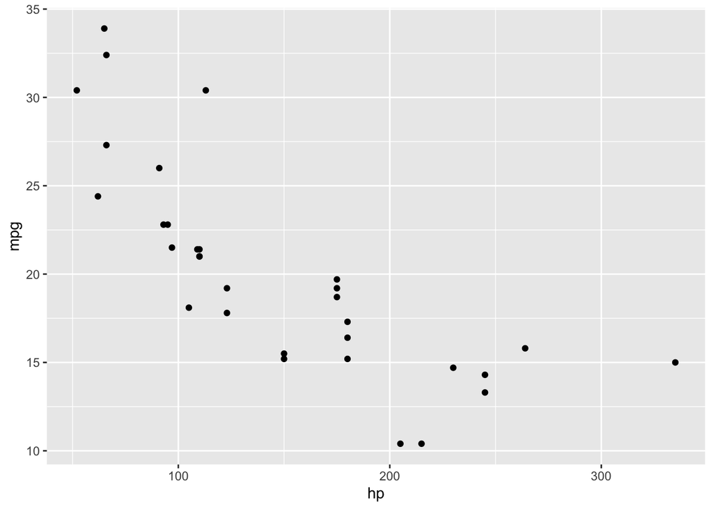

```r
ggplot(mtcars_new, aes(x = hp, y = mpg)) +
      geom_point()
```

The graph is quite simple, but we can make it more interesting by adding aesthetics. We will color the points by number of cylinders (`cyl`).

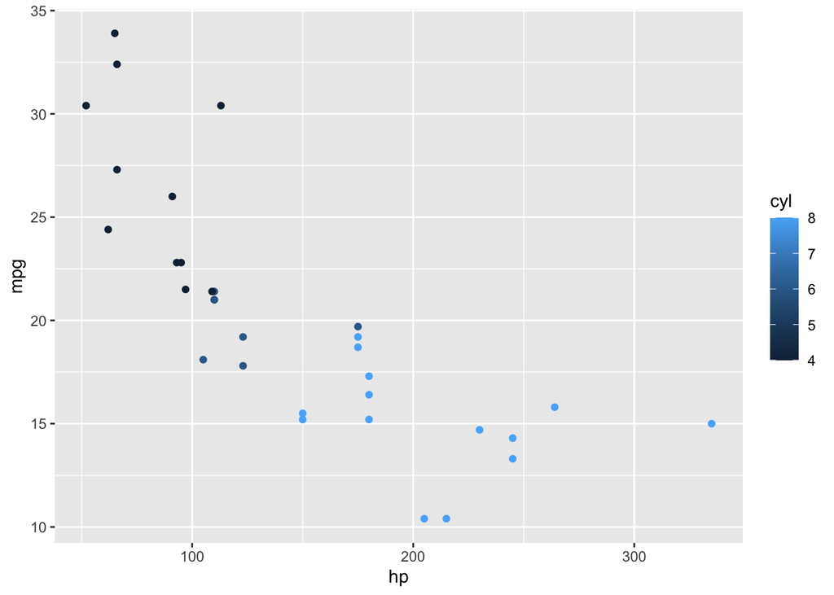

```r
ggplot(mtcars_new, aes(x = hp, y = mpg, color = cyl)) +
      geom_point()
```

The graph looks strange because ggplot is treating `cyl` as a continuous variable. We know it to be discrete; no car has a fraction of a cylinder. We can tell ggplot to treat the `cyl` variable as a factor with discrete levels using `as.factor()`.

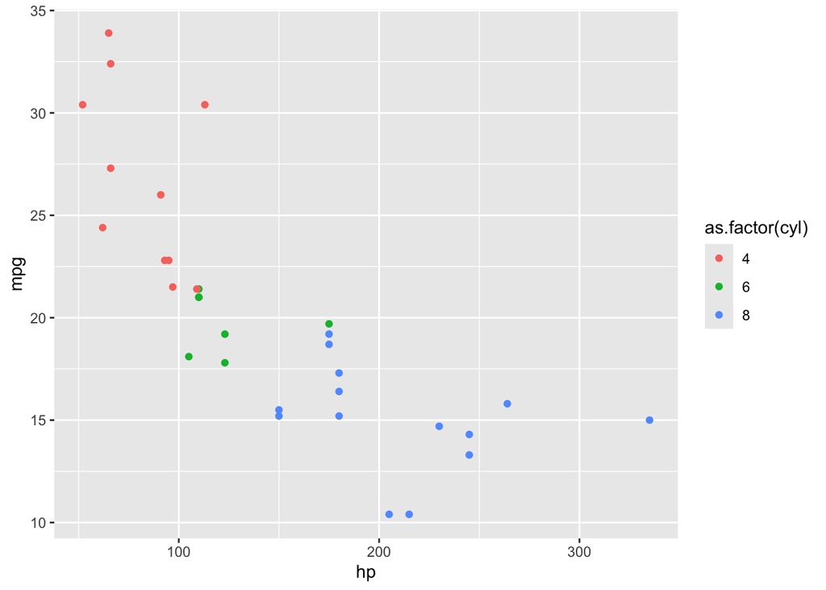

```r
ggplot(mtcars_new, aes(x = hp, y = mpg, color = as.factor(cyl))) +
      geom_point()
```

We can keep adding aesthetics. Engine displacement (`disp`) can be mapped to point size.

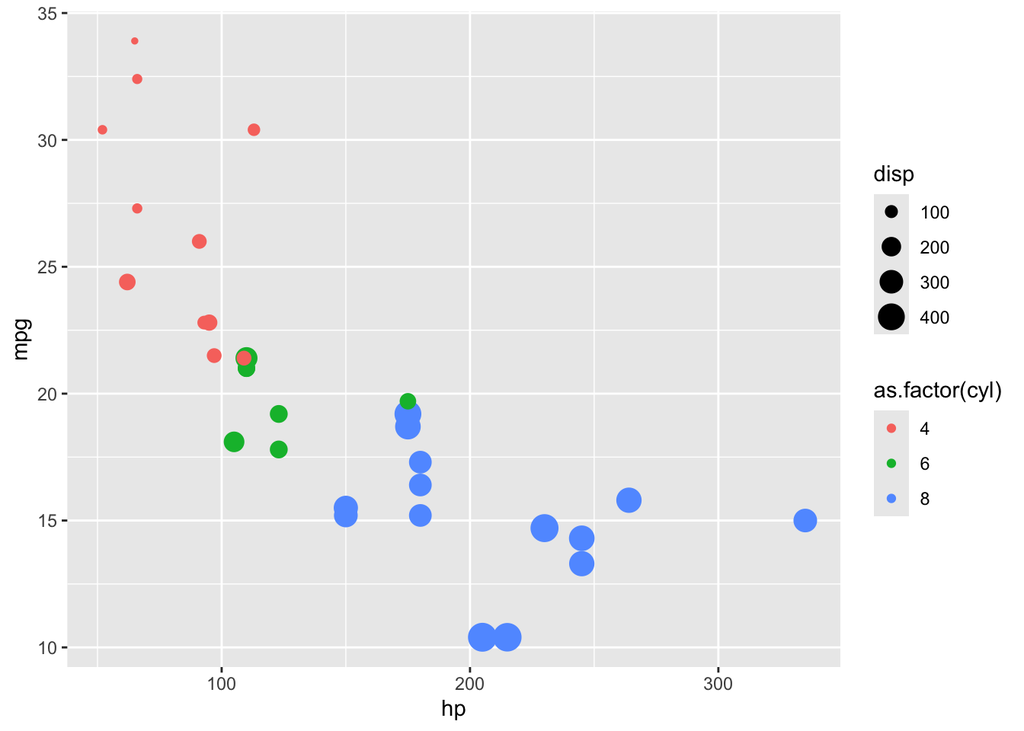

```r
ggplot(mtcars_new, aes(x = hp, y = mpg, color = as.factor(cyl), size = disp)) +
      geom_point()
```

Axis labels, legend, and other features can be customized. For example, points can be made more transparent using the `alpha` argument to `geom_point`.

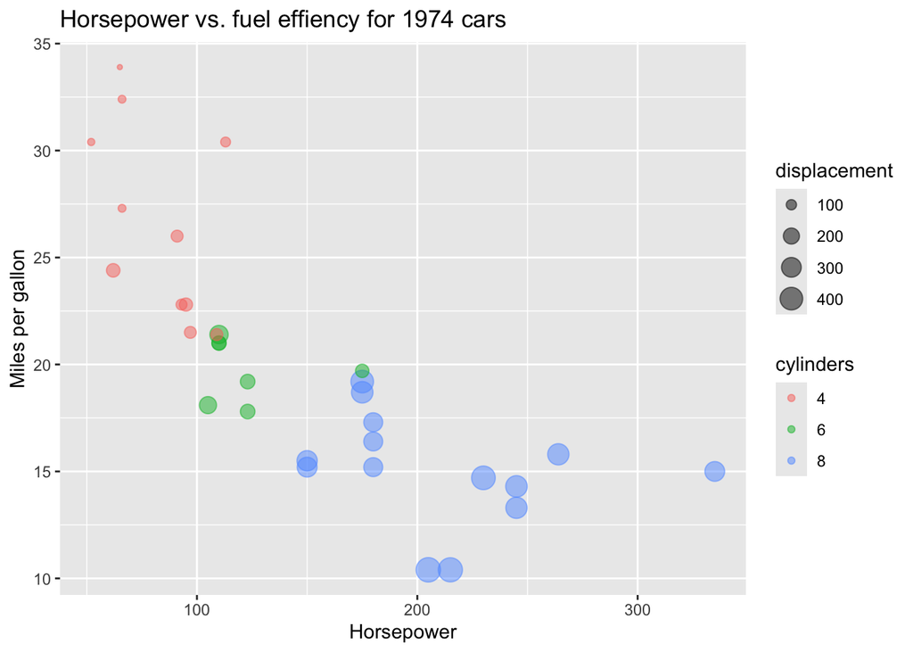

```r
ggplot(mtcars_new, aes(x = hp, y = mpg, color = as.factor(cyl), size = disp)) +
      geom_point(alpha = 0.5) +
      labs(x = "Horsepower", y = "Miles per gallon",
           title = "Horsepower vs. fuel effiency for 1974 cars",
           color = "cylinders", size = "displacement")
```

As we make the plot look better, we can save it as an object, then work with that object.

```r
mygraph <- ggplot(mtcars_new,
                  aes(x = hp, y = mpg, color = as.factor(cyl), size = disp)) +
      geom_point() +
      labs(x = "Horsepower", y = "Miles per gallon",
           title = "Horsepower vs. fuel effiency for 1974 cars",
           color = "cylinders", size = "displacement")
```

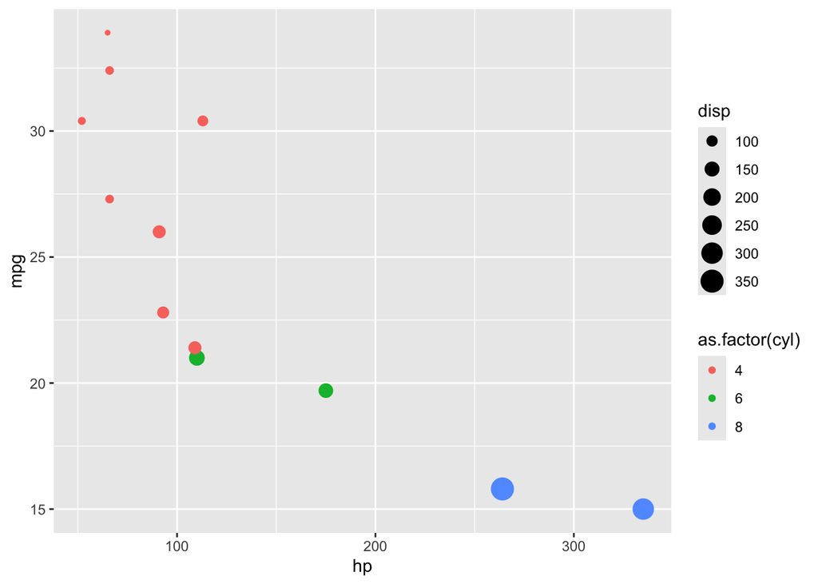

```r
# am == 1 denotes cars with manual transmission
mtcars_new %>%
      filter(am == 1) %>%
      ggplot(aes(x = hp, y = mpg, color = as.factor(cyl), size = disp)) +
      geom_point()
```

If the default settings are not appealing, we have many formatting options, including preset themes.

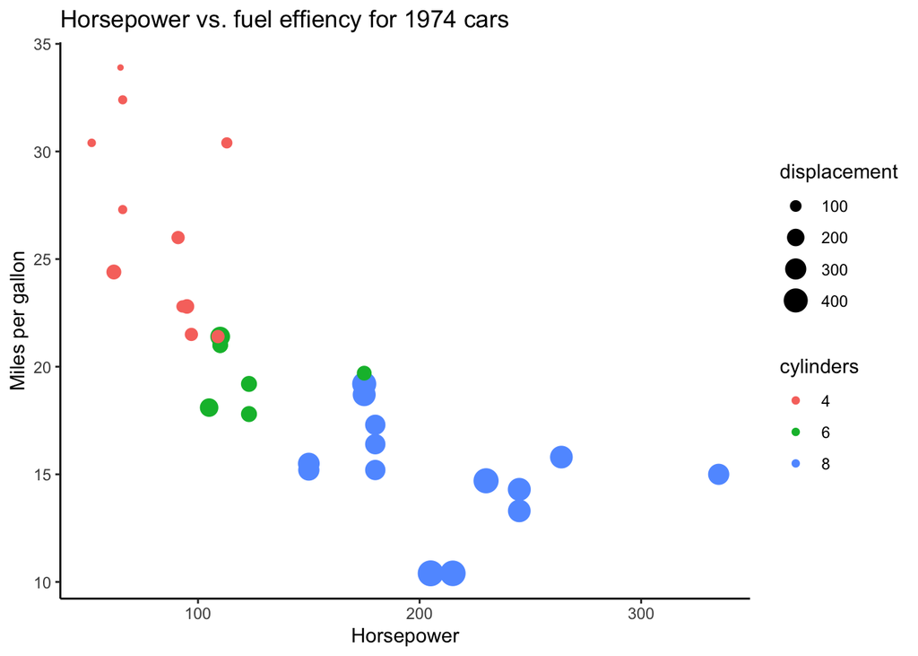

```r
mygraph +
      theme_classic()
```

Two plots side by side, separated into automatic and manual transmissions.

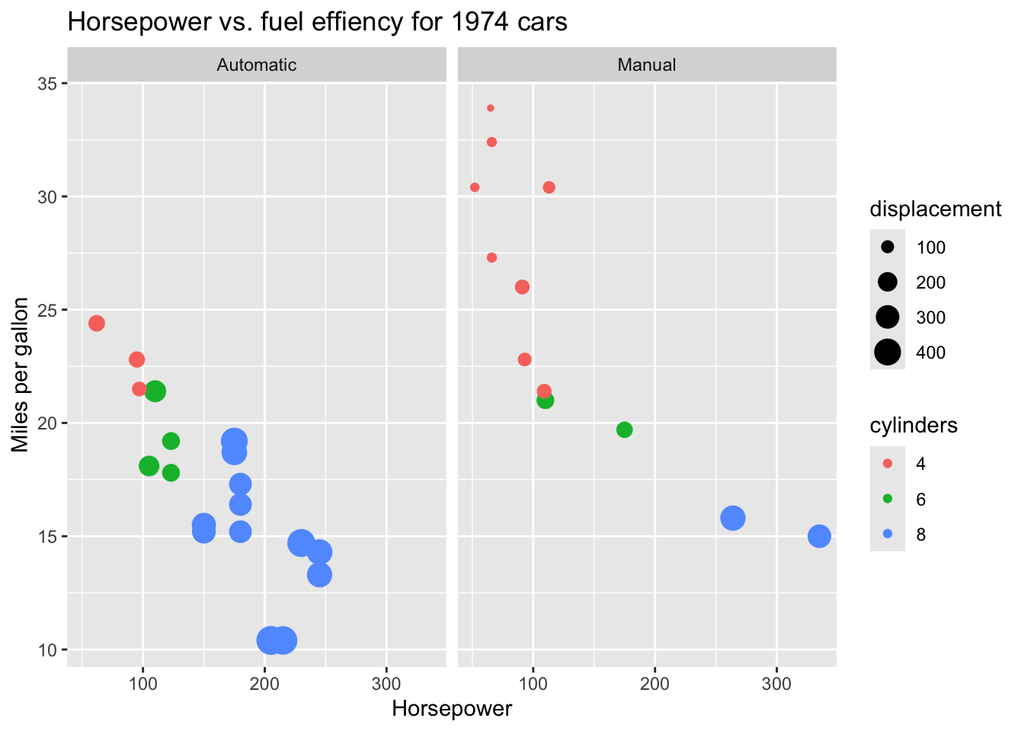

```r
mygraph +
      facet_grid(. ~ am, labeller = as_labeller(c(`0` = "Automatic", `1` = "Manual")))  # this creates a plot for each level of am
```

What do these graphs tell us about the characteristics of automatic and manual transmissions?